# RNAseAlert assay 07: substrate

Jan Sklenar

04/05/2020

# Efect of substrate batch on RNAseAlert assay

- We are testing two concentrations 1ul and 10ul. (The former is the recommended level)
- Joe’s substrate (brown tube) - very old
- New from the kit (50pmol per tube dry - dissolved in 60 ul of kit buffer)
- New in Apr 2020 (brown tube) in water (2uM in 1ml)

## Protocol:

[figure not shown]

Copy of the original Excel table.

#### Original RNAaseAlert kit manual

## Data preparation

### Read in the data and parse some sample names

```r
## read in raw data
raw <- read.delim("data/200504_RNAaseAlert_substrate2020-05-04T145821.txt",stringsAsFactors = FALSE)
colnames(raw)
```

```
##  [1] "Reading"        "Plate"          "Well"           "Type"
##  [5] "Group"          "Sample"         "Meas..time..s." "RFU"
##  [9] "Em"             "Ex"             "X"
```

```r
#' remove column
raw <- raw[,1:10]
#' change names
colnames(raw)[7]
```

```
## [1] "Meas..time..s."
```

```r
colnames(raw)[7] <- "MeasTimeSec"

#' parse 'Sample' to obtain sample number 'SampleNo'
raw$Sample[1]
```

```
## [1] "1 1/4"
```

```r
#substr(raw$Sample,1,regexpr(' ', raw$Sample)-1)
raw$SampleNo <- substr(raw$Sample,1,regexpr(' ', raw$Sample)-1)

#' in the same way extract replicate number - 'RepNo'
#substr(raw$Sample,regexpr(' ', raw$Sample)+1, regexpr('/', raw$Sample)-1)
raw$RepNo <- substr(raw$Sample,regexpr(' ', raw$Sample)+1, regexpr('/', raw$Sample)-1)

#' remove white space from 'Well' sting
#substr(raw$Well, 2, regexpr('$', raw$Well))[1:5]
raw$Well<- substr(raw$Well, 2, regexpr('$', raw$Well))
#' View(raw)
str(raw)
```

```
## 'data.frame':    420 obs. of  12 variables:
##  $ Reading    : int  1 1 1 1 1 1 1 1 1 1 ...
##  $ Plate      : int  1 1 1 1 1 1 1 1 1 1 ...
##  $ Well       : chr  "A09" "B09" "C09" "D09" ...
##  $ Type       : chr  "Unknown" "Unknown" "Unknown" "Unknown" ...
##  $ Group      : chr  "Assay" "Assay" "Assay" "Assay" ...
##  $ Sample     : chr  "1 1/4" "2 1/4" "3 1/4" "4 1/4" ...
##  $ MeasTimeSec: num  0 0.25 0.7 1.16 1.65 2.11 2.61 2.86 3.35 3.84 ...
##  $ RFU        : num  6.2 50.39 2.13 15.42 5.87 ...
##  $ Em         : int  520 520 520 520 520 520 520 520 520 520 ...
##  $ Ex         : int  490 490 490 490 490 490 490 490 490 490 ...
##  $ SampleNo   : chr  "1" "2" "3" "4" ...
##  $ RepNo      : chr  "1" "1" "1" "1" ...
```

### Corrections

Not this time.

### Subset of data for plotting

```r
## Selected (cleaned) data, only columns needed for plotting
#' Well, Sample, SampleNo, RepNo, MeasTimeSec, RFU
colnames(raw)
```

```
##  [1] "Reading"     "Plate"       "Well"        "Type"        "Group"
##  [6] "Sample"      "MeasTimeSec" "RFU"         "Em"          "Ex"
## [11] "SampleNo"    "RepNo"
```

```r
df <- raw[,c(3,6,7,8,11,12)]
head(df)
```

```
##   Well Sample MeasTimeSec      RFU SampleNo RepNo
## 1  A09  1 1/4        0.00  6.19597        1     1
## 2  B09  2 1/4        0.25 50.38950        2     1
## 3  C09  3 1/4        0.70  2.12549        3     1
## 4  D09  4 1/4        1.16 15.41540        4     1
## 5  E09  5 1/4        1.65  5.87052        5     1
## 6  F09  6 1/4        2.11 48.82530        6     1
```

```r
str(df)
```

```
## 'data.frame':    420 obs. of  6 variables:
##  $ Well       : chr  "A09" "B09" "C09" "D09" ...
##  $ Sample     : chr  "1 1/4" "2 1/4" "3 1/4" "4 1/4" ...
##  $ MeasTimeSec: num  0 0.25 0.7 1.16 1.65 2.11 2.61 2.86 3.35 3.84 ...
##  $ RFU        : num  6.2 50.39 2.13 15.42 5.87 ...
##  $ SampleNo   : chr  "1" "2" "3" "4" ...
##  $ RepNo      : chr  "1" "1" "1" "1" ...
```

## Plots

### All data

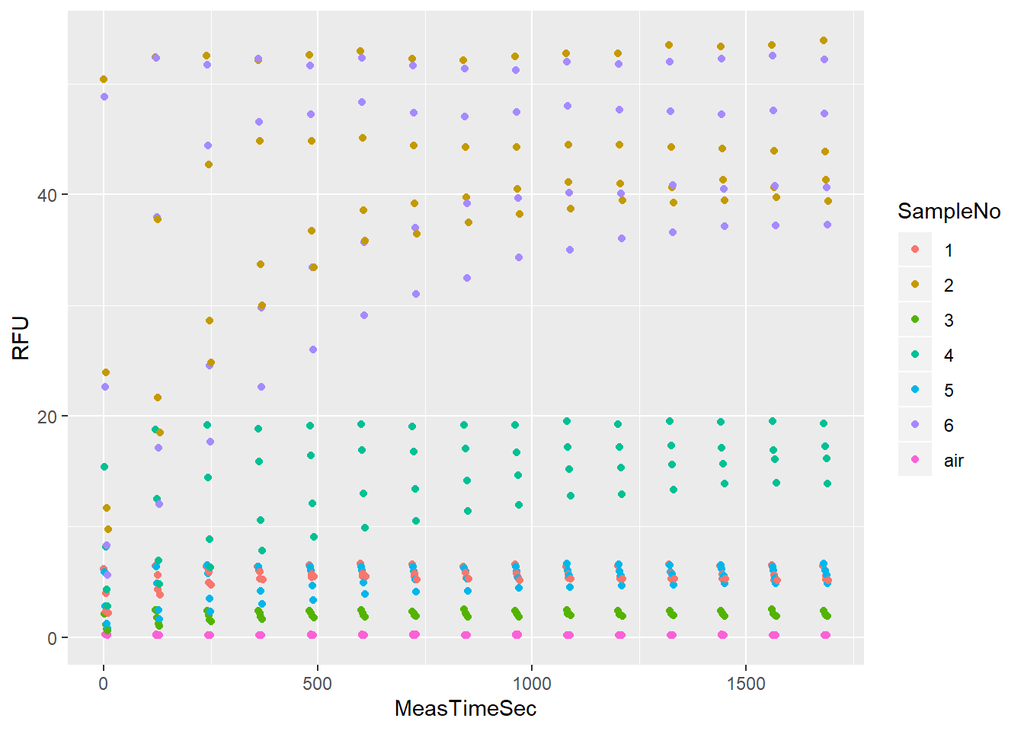

```r
#' all the data
#plot(x=raw$MeasTimeSec,y=raw$RFU)

#' colour labeled samples
ggplot(data = df) +
  aes(x = MeasTimeSec, y=RFU) +
  geom_point(aes(color=SampleNo))
```

### Adjustments (if needed)

Not this time. A limit on axis x is need. It will be added to plots later.

### All data with description

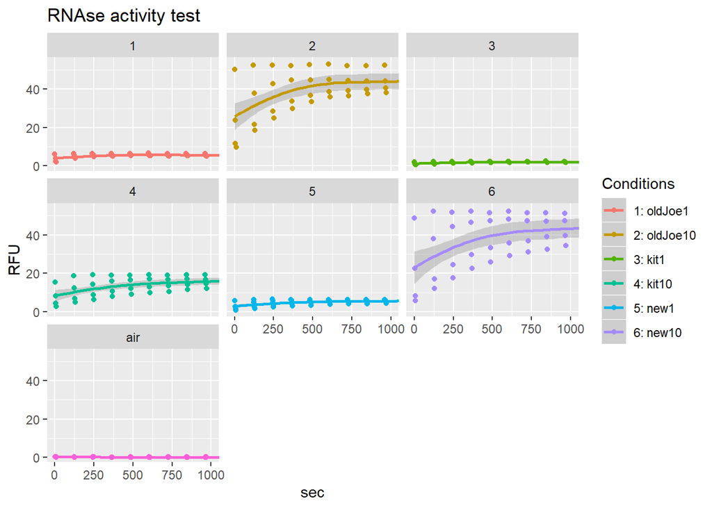

```r
## LOESS regression,
p <- ggplot(data = df) +
  aes(x = MeasTimeSec, y=RFU) +
  geom_smooth(aes(color=SampleNo)) +
  geom_point(aes(colour=SampleNo))

#' Panel of plots
p+facet_wrap(~SampleNo) +
  coord_cartesian(xlim = c(0,1000)) +
  labs(title = "RNAse activity test", x = "sec", y = "RFU") +
  scale_colour_discrete(name="Conditions",
                        breaks=c(1,2,3,4,5,6,7,8),
                        labels=c("1: oldJoe1",
                                 "2: oldJoe10",
                                 "3: kit1",
                                 "4: kit10",
                                 "5: new1",
                                 "6: new10",
                                 "7: air",
                                 "8: air"))
```

```r
#' All conditions together
  p + labs(title = "RNAse activity test", x = "sec",   y = "RFU", color = "Legend Title\n") +
  coord_cartesian(xlim = c(0,1000)) +
  scale_colour_discrete(name="Conditions",
                      breaks=c(1,2,3,4,5,6,7,8),
                      labels=c("1: oldJoe1",
                                 "2: oldJoe10",
                                 "3: kit1",
                                 "4: kit10",
                                 "5: new1",
                                 "6: new10",
                                 "7: air",
                                 "8: air"))
```

[figure not shown]

### Plots of subsets of selected conditions being tested

```r
## positive contorls vs some negative controls
p <- df[raw$SampleNo==1|df$SampleNo==2|df$SampleNo==3|df$SampleNo==4|df$SampleNo==5|df$SampleNo==6|df$SampleNo==7|df$SampleNo==7,]
## LOESS regression
p <- ggplot(data = p) +
  aes(x = MeasTimeSec, y=RFU) +
  geom_smooth(aes(color=SampleNo)) +
  geom_point(aes(colour=SampleNo))


p + labs(title = "RNAse activity test", x = "sec",   y = "RFU", color = "Legend Title\n") +
  coord_cartesian(xlim = c(0,1000)) +
  scale_colour_discrete(name="Conditions",
                      breaks=c(1,2,3,4,5,7,8),
                      labels=c("1: oldJoe1",
                                 "2: oldJoe10",
                                 "3: kit1",
                                 "4: kit10",
                                 "5: new1",
                                 "6: new10",
                                 "7: air",
                                 "8: air"))
```

[output not shown]

## Conclutions

- All substrates work, even the old one.
- For a decent signal, higher concentration than recommended is needed.
- Reaction kinetics is interesting with benzoase, very steep in fist few minutes. Presumably low copy number oftarget RNA in a real sample will prevent this from happening.
- Reactions in the replicates were started in the order 1,2,3,4. The small delay is likely the reason for the trend in some measurments. This is apparent in tests with 10 fold the recommended substrate concentration.

### What’s next:

Test buffer compatibility.